# San Francisco Crimes Investigation

Andrei Iusan

*Exploratory Data Analysis* *of [The San Francisco Crimes dataset](https://www.kaggle.com/c/sf-crime).*

# Overview of the Data

First I’ll look at the dimensions of the data-set:

```
## [1] 878049      9
```

There are 878049 observations of 9 features. Those features are:

```
## [1] "Dates"      "Category"   "Descript"   "DayOfWeek"  "PdDistrict"
## [6] "Resolution" "Address"    "X"          "Y"
```

I’d like to see the structure of the data:

```
## 'data.frame':    878049 obs. of  9 variables:
##  $ Dates     : Factor w/ 389257 levels "2003-01-06 00:01:00",..: 389257 389257 389256 389255 389255 389255 389255 389255 389254 389254 ...
##  $ Category  : Factor w/ 39 levels "ARSON","ASSAULT",..: 38 22 22 17 17 17 37 37 17 17 ...
##  $ Descript  : Factor w/ 879 levels "ABANDONMENT OF CHILD",..: 867 811 811 405 405 407 740 740 405 405 ...
##  $ DayOfWeek : Factor w/ 7 levels "Friday","Monday",..: 7 7 7 7 7 7 7 7 7 7 ...
##  $ PdDistrict: Factor w/ 10 levels "BAYVIEW","CENTRAL",..: 5 5 5 5 6 3 3 1 7 2 ...
##  $ Resolution: Factor w/ 17 levels "ARREST, BOOKED",..: 1 1 1 12 12 12 12 12 12 12 ...
##  $ Address   : Factor w/ 23228 levels "0 Block of 10TH AV",..: 19810 19810 22674 4267 2087 1506 13323 18055 11389 17659 ...
##  $ X         : num  -122 -122 -122 -122 -122 ...
##  $ Y         : num  37.8 37.8 37.8 37.8 37.8 ...
```

Now I’ll print a summary of the data-set:

```
##                  Dates                  Category
##  2011-01-01 00:01:00:   185   LARCENY/THEFT :174900
##  2006-01-01 00:01:00:   136   OTHER OFFENSES:126182
##  2012-01-01 00:01:00:    94   NON-CRIMINAL  : 92304
##  2006-01-01 12:00:00:    63   ASSAULT       : 76876
##  2007-06-01 00:01:00:    61   DRUG/NARCOTIC : 53971
##  2006-06-01 00:01:00:    58   VEHICLE THEFT : 53781
##  (Other)            :877452   (Other)       :300035
##                                   Descript          DayOfWeek
##  GRAND THEFT FROM LOCKED AUTO         : 60022   Friday   :133734
##  LOST PROPERTY                        : 31729   Monday   :121584
##  BATTERY                              : 27441   Saturday :126810
##  STOLEN AUTOMOBILE                    : 26897   Sunday   :116707
##  DRIVERS LICENSE, SUSPENDED OR REVOKED: 26839   Thursday :125038
##  WARRANT ARREST                       : 23754   Tuesday  :124965
##  (Other)                              :681367   Wednesday:129211
##       PdDistrict                 Resolution
##  SOUTHERN  :157182   NONE             :526790
##  MISSION   :119908   ARREST, BOOKED   :206403
##  NORTHERN  :105296   ARREST, CITED    : 77004
##  BAYVIEW   : 89431   LOCATED          : 17101
##  CENTRAL   : 85460   PSYCHOPATHIC CASE: 14534
##  TENDERLOIN: 81809   UNFOUNDED        :  9585
##  (Other)   :238963   (Other)          : 26632
##                      Address             X                Y
##  800 Block of BRYANT ST  : 26533   Min.   :-122.5   Min.   :37.71
##  800 Block of MARKET ST  :  6581   1st Qu.:-122.4   1st Qu.:37.75
##  2000 Block of MISSION ST:  5097   Median :-122.4   Median :37.78
##  1000 Block of POTRERO AV:  4063   Mean   :-122.4   Mean   :37.77
##  900 Block of MARKET ST  :  3251   3rd Qu.:-122.4   3rd Qu.:37.78
##  0 Block of TURK ST      :  3228   Max.   :-120.5   Max.   :90.00
##  (Other)                 :829296
```

This summary offers some insight, but not an overall picture of the data set. There are many categories for each feature, so we can only see the categories with the most elements. For instance, we can instantly see that the most common crime is theft, from description we can see that the most common is “GRAND THEFT FROM LOCKED AUTO”. Southern district seems to be the district with the highest criminal activity, and there is an unusually high number of crimes at the 800 Block of BRYANT ST. Also, there is an unusually high number of crimes on 1st of January, especially on 2011 and 2006. I will explore those insights in more detail through visualizations.

Let’s also have a look at a few entries in this data set:

```
##                 Dates       Category                       Descript
## 1 2015-05-13 23:53:00       WARRANTS                 WARRANT ARREST
## 2 2015-05-13 23:53:00 OTHER OFFENSES       TRAFFIC VIOLATION ARREST
## 3 2015-05-13 23:33:00 OTHER OFFENSES       TRAFFIC VIOLATION ARREST
## 4 2015-05-13 23:30:00  LARCENY/THEFT   GRAND THEFT FROM LOCKED AUTO
## 5 2015-05-13 23:30:00  LARCENY/THEFT   GRAND THEFT FROM LOCKED AUTO
## 6 2015-05-13 23:30:00  LARCENY/THEFT GRAND THEFT FROM UNLOCKED AUTO
##   DayOfWeek PdDistrict     Resolution                   Address         X
## 1 Wednesday   NORTHERN ARREST, BOOKED        OAK ST / LAGUNA ST -122.4259
## 2 Wednesday   NORTHERN ARREST, BOOKED        OAK ST / LAGUNA ST -122.4259
## 3 Wednesday   NORTHERN ARREST, BOOKED VANNESS AV / GREENWICH ST -122.4244
## 4 Wednesday   NORTHERN           NONE  1500 Block of LOMBARD ST -122.4270
## 5 Wednesday       PARK           NONE 100 Block of BRODERICK ST -122.4387
## 6 Wednesday  INGLESIDE           NONE       0 Block of TEDDY AV -122.4033
##          Y
## 1 37.77460
## 2 37.77460
## 3 37.80041
## 4 37.80087
## 5 37.77154
## 6 37.71343
```

Interestingly, it seems that the first two entries refer to the same event. There are two entries from the same time and place, but with different description, and different categories. I’ll have to perform some data aggregation to find out how many events are in this data-set.

I’ll consider that multiple entries in this data set describe the same event if the Date and Location are the same. Given this rule, how many events are in our data set?

```
## [1] 688901
```

# Univariate Analysis

Let’s explore some of those variables in more detail.

### Main features of interest

The most interesting variables are **Category** and **Resolution**. All other variables describe the context of the crime, but most important is the crime itself, and the resolution. In a sense those are the dependent variables. I would like to describe those variables in terms of distribution in time, space, in order to see trends of criminal behaviour and police behaviour.

Have certain crimes became more common than others? Did the SFPD changed its reaction to certain crimes? (By being more severe or more lenient to certain crimes)

The number of crimes in each category:

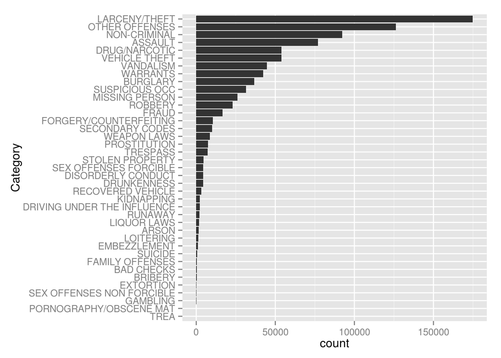

The most common crime is theft, followed by *Other Offenses* and *Non-Criminal*. Those are vague general categories that I will investigate further, and possibly move some events to other categories. The next most common specific crimes are *Assault*, *Drug/Narcotic* and *Vehicle Theft*. I think *Vechicle Theft* could be a sub-category of *Larceny/Theft*.

Next I explore the distribution of resolutions:

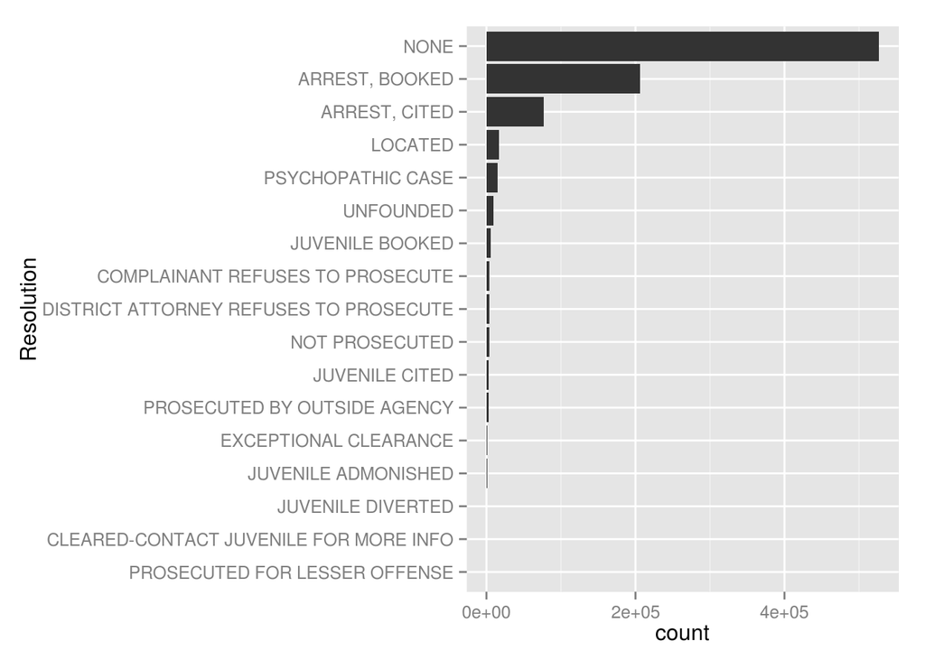

I find it interesting that most crimes have no resolution, followed by a high number of arrests. I’ll rescale this plot to a logarithmic scale, so we can better see the variability among the categories with low number of cases:

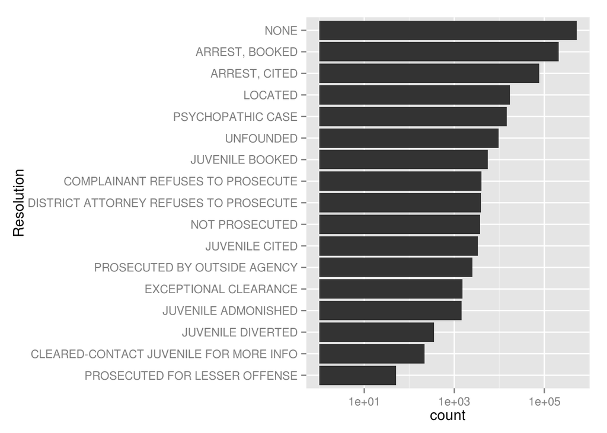

Crimes by day of week:

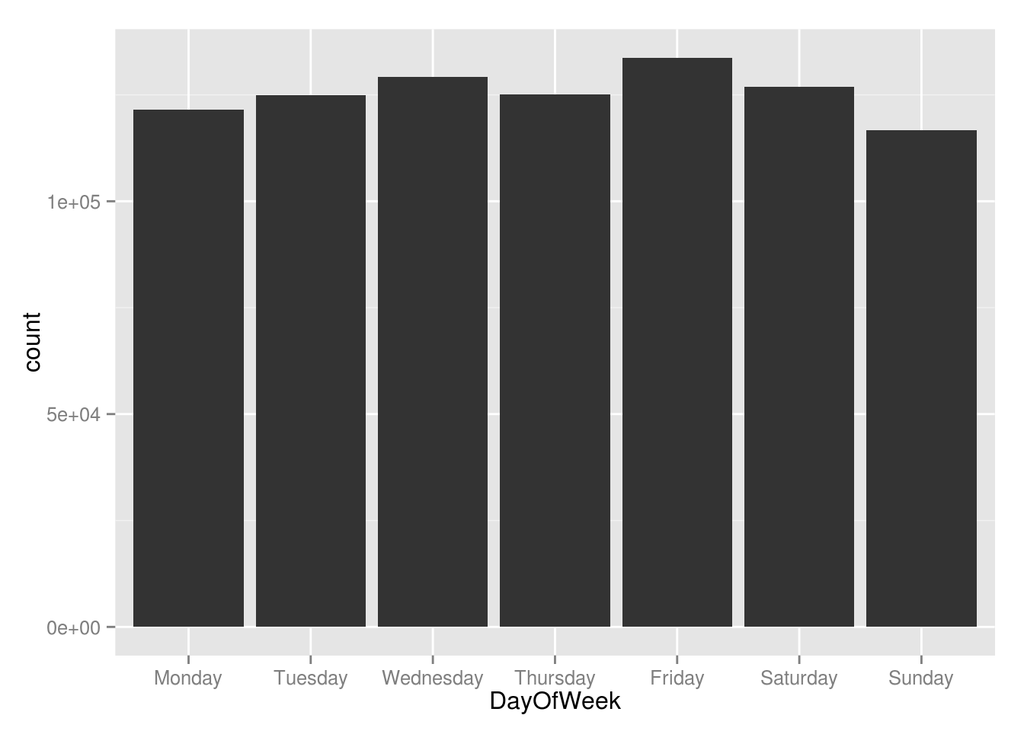

There doesn’t seem to be a noticeable difference among days of week.

Crimes by district:

[figure not shown]

```r
ggplot(data = crimes, aes(x = PdDistrict)) +
  geom_bar() +
  coord_flip()
```

The differences among different districts are noticeable, there is wide variability among districts with respect to the criminal activity.

Those plots provide an overview of all the data, but I would like to see more specific trends, like what crimes are most likely to be resolved, or how the criminal activity varies across the time, and across different areas of the city.

### Crimes over time

How do crimes vary across time? Is there a general increasing or decreasing trend? How do they vary by month? Or by hour? Are there fluctuating patterns? We saw that by day of week there doesn’t seem to be a pattern.

To answer the question regarding the trend, I will plot the number of crimes for each month.

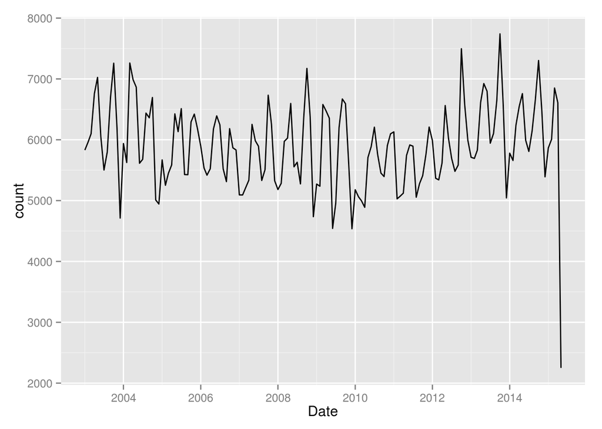

There seems to be a yearly pattern. We can better observe this if we plot all yearly periods on top of each other.

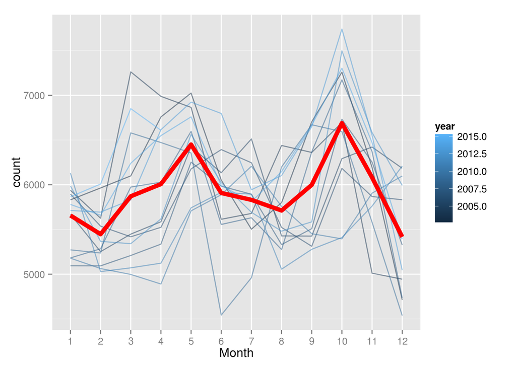

The red line represents the mean of monthly crimes from all years. The thin shaded lines represent the number of crimes for each year. There are two peaks, in May and October.

How about hourly trends? I suspect there should be a lot of variability among hours. I will calculate the average over all days like in the previous plot, but I show only the average line.

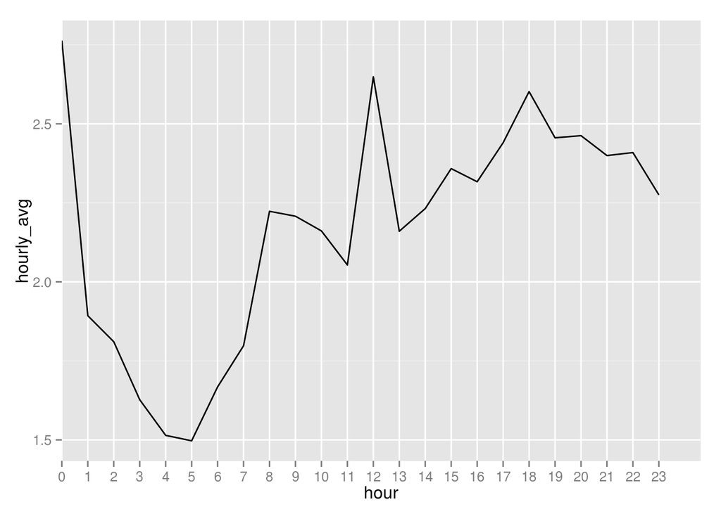

Interesting pattern, not a lot of crimes happen during the night, but the highest number of them happen around midnight. Is it safer to walk around at 3 or 4 in the morning than at midday? To answer this question I will have to plot this again but with data filtered, to exclude crimes that are not physically harming, like fraud, forgery, etc.

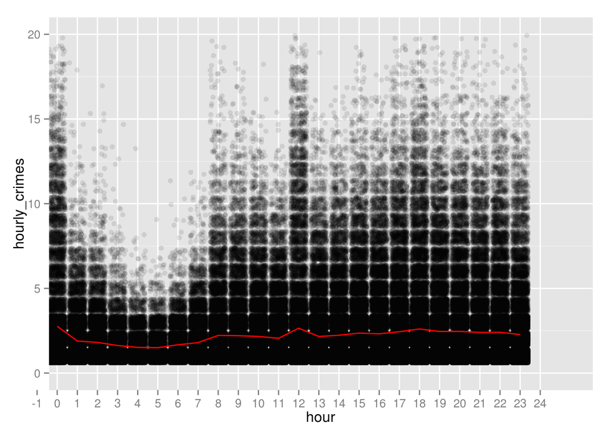

### More variables, digging deeper into details of the data.

I’ll explore a couple of the most common crimes. I’ll start with the most common: Larceny/Theft

### Theft

I’d like to see the descriptions of all theft entries:

```
##  [1] GRAND THEFT FROM LOCKED AUTO
##  [2] GRAND THEFT FROM UNLOCKED AUTO
##  [3] PETTY THEFT FROM LOCKED AUTO
##  [4] ATTEMPTED THEFT FROM LOCKED VEHICLE
##  [5] PETTY THEFT SHOPLIFTING
##  [6] GRAND THEFT FROM PERSON
##  [7] PETTY THEFT FROM A BUILDING
##  [8] GRAND THEFT OF PROPERTY
##  [9] GRAND THEFT FROM A BUILDING
## [10] PETTY THEFT OF PROPERTY
## [11] GRAND THEFT SHOPLIFTING
## [12] THEFT OF ANIMALS (GENERAL)
## [13] PETTY THEFT BICYCLE
## [14] GRAND THEFT BICYCLE
## [15] ATTEMPTED THEFT OF A BICYCLE
```

[output cut: 48 more lines]

# TO DO:

- as.POSIXct(Dates)
- box plots of crimes by hour
- show resolution / no resolution by category
- relationship between category and pdDistrict (facet, top 5, maybe time-data)
- categories on map of city
- resolution percentage by district (over time?)
- category vs resolution (heat map: category on one axis, resolution on another, squares in the grid indicate how frequently the two appear together)

# Bivariate Plots Section

# Bivariate Analysis

# Multivariate Plots Section

# Multivariate Analysis

# Final Plots and Summary

# Reflection